# Principios y Prácticas de SEM y MLM (5ed)

Tema 4.1 Introducción a los Modelos Mixtos o Multinivel

Author

Affiliation

Efraín García Sánchez

CIMCYC — Universidad de Granada

Published

May 29, 2026

# Principios

## ¿Qué son los modelos mixtos o multinivel?

> Los modelos multinivel (o de efectos mixtos) son modelos de regresión que tienen en cuenta la dependencia entre observaciones al permitir que los parámetros del modelo varíen entre grupos o unidades de nivel superior.
- Varios nombres
  - Multilevel regresssion models
  - Linear mixed model (LME)
  - Mixed model/effects
  - Random effects model
  - Random coefficients model
  - Hierarchical lineal model
  - Variance component model
  - Contextual analyses
- Modelo
  - Extensión de la regresión lineal
  - Datos anidados o jerárquicos (niveles)
  - Relaciones entre diferentes niveles de análisis (e.g., intra-, entre-)
  - Combina efectos fijos y aleatorios (efectos promedio y su heterogeneidad)

## Limitaciones de los Modelos de Regresión Lineal

- La regresión lineal asume la independencia de las observaciones
- Pero esto no siempre se cumple, por tanto…

#### **Estima parámetros sesgados**

- Viola supuesto de independencia de las observaciones
  - Residuos no son aleatorios
- Aumenta el riesgo del error Tipo I
  - Falso positivo: asume que hay un efecto cuando no lo hay
  - Errores estándar más bajos = pruebas estadísticas más altas
  - Ejemplo: 100 personas x 10 medidas != 1,000 observaciones
- Si sólo se usan las unidades de agrupación (e.g., personas, grupos, etc.)
  - Se pierde variabilidad e información valiosa

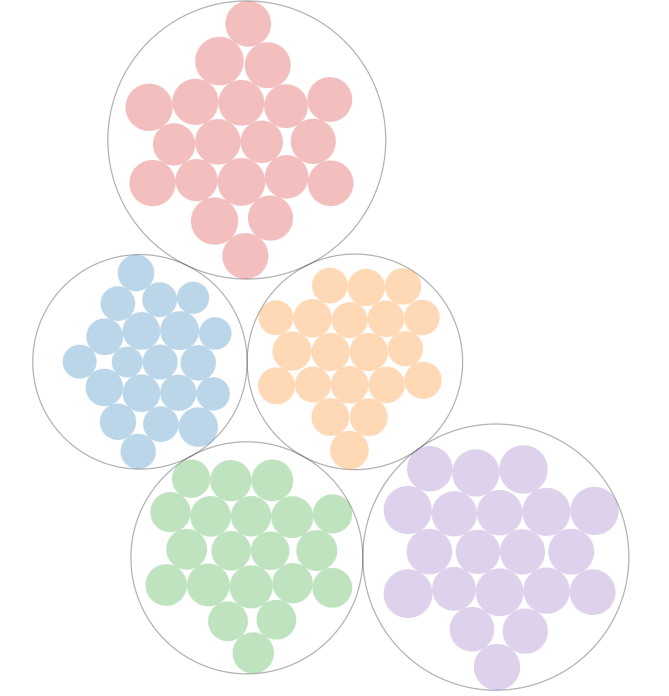

## Otras limitaciones conceptuales o metodológicas

#### Falacia ecológica

> Asumir que una relación encontrada a nivel de grupo también existe necesariamente a nivel individual.
- Los **contextos** más pobres suelen tener mayores niveles de criminalidad
- PERO Las **personas** más pobres NO suelen ser criminales

> No se puede inferir una asociación de un nivel hacia el otro

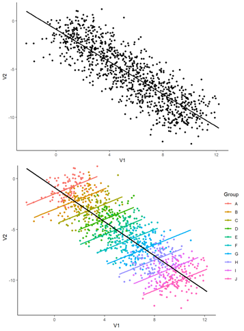

## Otras limitaciones conceptuales o metodológicas

#### “Frog pond” effect

> “No es lo mismo ser una rana grande en un estanque pequeño que una rana pequeña en un estanque grande”.

> el resultado individual de una persona o caso depende de su posición relativa dentro del grupo al que pertenece.

— **Autoeficacia**: Una persona con mucha capacidad se siente menos eficaz en un entorno muy competitivo (vs. menos competitivo)

*Nota: El efecto del entorno*

[figure not shown]

## Oportunidades de los modelos mixtos/multinivel: Teoría

#### Las preguntas incluyen una teoría o un fenómeno multinivel

> Cuando la explicación del fenómeno combina procesos en diferentes niveles (e.g., intra-sujeto, entre individuos, entre contextos, etc.)
- Fenómenos, Teorías, constructos y/o variables a diferentes niveles (e.g., el clima organizacional, las condiciones atmosféricas, el tipo de tarea, etc.)

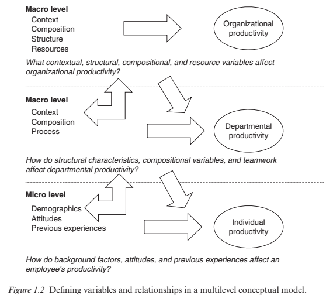

## Oportunidades de los modelos mixtos/multinivel: El Diseño

#### El *diseño* de la investigación y la *estructura* de los datos están anidados

- Diseños intrasujeto, medidas repetidas, longitudinales, etc.
- Datos anidados, jerarquizados, agrupados, dependientes, etc.

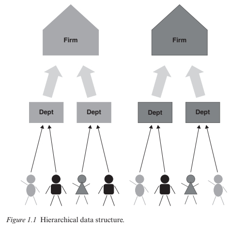

## Tipos de preguntas de investigación en modelos mixtos o multinivel (1)

- Efectos **directos** en diferentes niveles
- Efectos **condicionados** o moderaciones
- Efectos **indirectos** o mediaciones
- Efectos de longitudinales o de crecimiento (*growth models*)

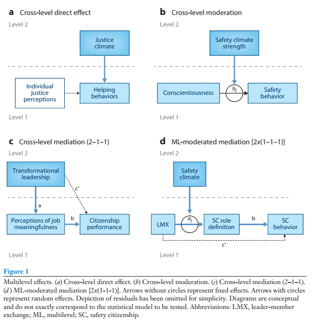

## Tipos de preguntas de investigación en modelos mixtos o multinivel (2)

| Tipo | Pregunta central | Ejemplo |
| --- | --- | --- |
| Directos | ¿X predice Y? | ¿El estrés predice bienestar? |
| Contextuales | ¿El grupo afecta al individuo? | ¿El clima escolar predice el rendimiento? |
| Moderaciones | ¿El efecto de X depende de Z? | ¿El apoyo reduce el efecto del estrés sobre el rendimiento? |
| *Cross-level* | ¿El contexto cambia un efecto individual? | ¿El clima de equipo amortigua la carga laboral? |
| Mediaciones | ¿X afecta Y vía M? | ¿El liderazgo mejora bienestar a través del clima? |
| Crecimiento | ¿Cómo cambia Y en el tiempo? | ¿Disminuyen los síntomas con tratamiento en el tiempo? |
| Pendientes aleatorias | ¿El efecto de X varía entre grupos? | ¿El efecto del ingreso sobre el desempeño varía entre escuelas? |

## Tipos de MLM [(Hoffman, 2015)](https://www.routledge.com/Longitudinal-Analysis-Modeling-Within-Person-Fluctuation-and-Change/Hoffman/p/book/9780415876025)

| Tipo de modelo | Qué estructura analiza | Pregunta típica | Ejemplo |
| --- | --- | --- | --- |
| **Clustered models** | Observaciones anidadas jerárquicamente en grupos | ¿Los individuos dentro de un mismo grupo se parecen entre sí? | Estudiantes dentro de colegios |
| **Cross-classified models** | Observaciones pertenecen simultáneamente a más de un grupo no anidado | ¿El resultado depende de varios contextos al mismo tiempo? | Estudiantes vinculados a colegios y barrios |
| **Growth curve models** | Mediciones repetidas anidadas dentro de personas o unidades (+ unidad de tiempo) | ¿Cómo cambia un resultado en el tiempo y quién cambia más rápido? | Cambio en actitudes políticas durante a lo largo del tiempo |
| **Within-person variation models** | Fluctuaciones temporales dentro de la misma persona | ¿Cuando una persona cambia respecto a su propio promedio, cambia también otro resultado? | Días de más estrés que lo habitual y emociones negativas |

## ¿Cómo se representa un MLM?

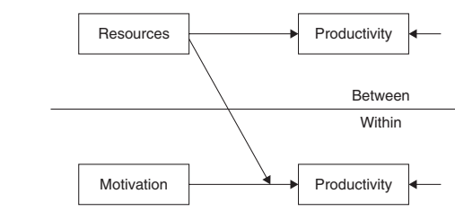

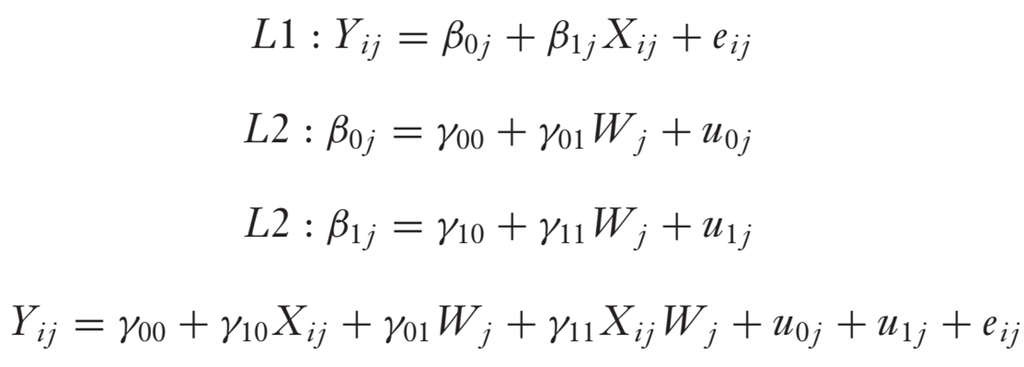

# Teoría y Práctica

## Preparar el ambiente de trabajo

```r
# Instalar el paquete

# install.packages("glmmTMB")
# install.packages("glmmTMB", type="source")

# Cargar los paquetes
library(tidyverse)
library(easystats)
library(glmmTMB)

# Verificar que el paquete `glmmTMB` cargue correctamente
```

## La pregunta de investigación ([Naragon-Gainey et al., 2023](https://journals.sagepub.com/doi/10.1177/21677026221147262))

[figure not shown]

## Los datos ([OpenESM](https://openesmdata.org/datasets/0058_gainey/))

| Variable | Constructo | Items/base | Interpretación |
| --- | --- | --- | --- |
| `wellbeing` | Bienestar | significado, vitalidad | Mayor = más bienestar |
| `decentering` | Descentramiento | observar, distanciarse, no luchar, no quedar atrapado | Mayor = más distancia psicológica |
| `positive_affect` | Afecto positivo | activo, interesado, emocionado, fuerte | Mayor = más afecto positivo |
| `negative_affect` | Afecto negativo | irritable, molesto, ansioso, triste | Mayor = más afecto negativo |
| `dysphoria` | Disforia | deprimido, anhedonia, inadecuado, desanimado | Mayor = más síntomas disfóricos |
| `BFI_O` | Personalidad | apertura a la experiencia | Mayor = más apertura |
| `BFI_C` | Personalidad | responsabilidad / escrupulosidad | Mayor = más responsabilidad |
| `BFI_E` | Personalidad | extraversión | Mayor = más extraversión |
| `BFI_A` | Personalidad | amabilidad | Mayor = más amabilidad |
| `BFI_N` | Personalidad | neuroticismo | Mayor = más neuroticismo |
| `gender_female` | Género | `Sex` recodificada | 1 = mujer, 0 = hombre |
| `day_cen` | Tiempo | `day - 1` | 0 = día 1, 6 = día 7 |

## Importar los datos

```r
data <- readr::read_csv(
  here::here("data",
             "data_mlm",
             "data_naragon_2023.csv")
  ) |>
  round(2)

# ver la estructura de los datos
glimpse(data)
```

## Explorar los datos

- 379 personas
- 7 medidas por persona
- 2653 observaciones en total

```r
data |>
  count(id)
```

## Tener los datos en el formato correcto (*long format*)

- Formato largo
  - Se repite la variable de agrupamiento
    - Contextos
    - Items/tareas
    - Personas (medidas repetidas o longitudinal)

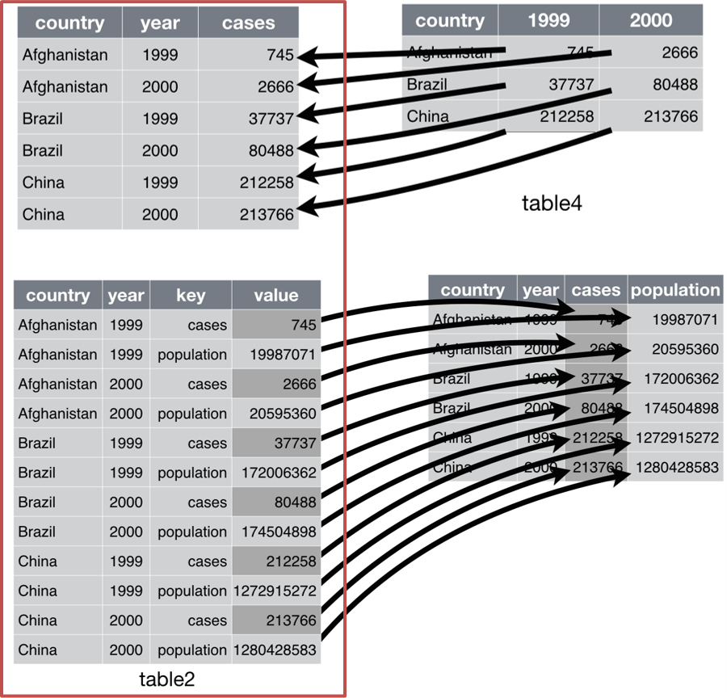

## Tener los datos en el formato correcto (*long format*)

```r
data |>
  select(id, day_cen, wellbeing, dysphoria, positive_affect) |>
  filter(id %in% c(102, 103)) |>
  display()
```

## Componentes de los MLM: Diferencias entre sujetos e intrasujetos

- Las medias y las desviaciones típicas indican diferencias entre e intra personas

```r
data |>
  select(id, wellbeing, dysphoria) |>
  filter(id %in% c(102, 103, 104)) |>
  psych::describeBy(group = "id", fast = TRUE)
```

## Componentes de de los modelos multinivel: Efectos fijos y aleatorios

#### Efectos fijos

- *Model for the mean*
- Parámetros estimados del modelo (intercepto, pendientes)
- Representan efectos constantes para todos los grupos (valores promedio)
- Describen el patrón promedio en la población o muestra.

#### Efectos aleatorios

- *Model for the variance*
- Representan desviaciones o residuos asociados a los parámetros (intercepto, pendientes)
- Estiman cuánta variabilidad existe entre grupos en el nivel inicial o en los efectos de ciertos predictores.

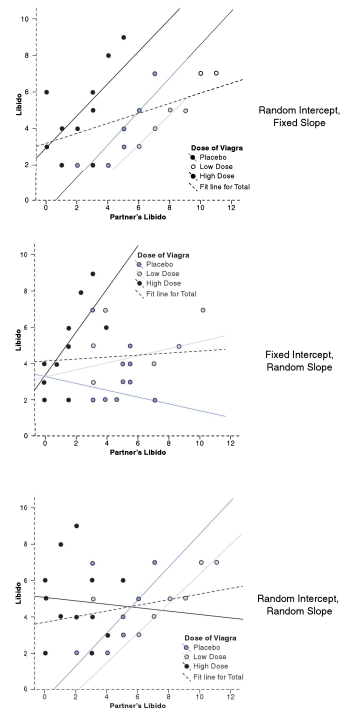

## Ejemplo: Efectos fijos y aleatorios en nuestros datos

```r
data |>
  drop_na(wellbeing) |>
  filter(id %in% sample(unique(id), 16)) |> # muestra de algunos participantes
  ggplot(aes(x = day_cen, y = wellbeing, group = id)) +
  geom_line() +
  geom_point() +
  facet_wrap(~ id) +
  geom_smooth(method = "lm", se = FALSE) +
  scale_x_continuous(breaks = c(0:6)) +
  theme_classic()
```

[output not shown]

## Ejemplo: Efectos fijos y aleatorios en nuestros datos

```r
set.seed(270526)

data |>
  drop_na(wellbeing) |>
  filter(id %in% sample(unique(id), 16)) |>
  ggplot(aes(x = day_cen, y = wellbeing, group = id, color = as.factor(id))) +
  geom_smooth(method = "lm", se = FALSE) +
  scale_x_continuous(breaks = c(0:6)) +
  theme_classic() +
  labs(color = "Participante") +
  geom_smooth(
  data = data |> drop_na(wellbeing) , # para adicionar la tendencia general
  aes(x = day_cen, y = wellbeing),
  inherit.aes = FALSE,
  method = "lm",
  se = FALSE,
  color = "black",
  linewidth = 3
)
```

[output not shown]

## Estimar el modelo: Estrategias

#### *Bottom-up*

- Modelos más simple (just-intercept) [(Heck & Thomas, 2020)](https://www.routledge.com/An-Introduction-to-Multilevel-Modeling-Techniques-MLM-and-SEM-Approaches/Heck-Thomas/p/book/9780367182441)
- Adicionar parte fija + aleatoria
- Cada paso permite determinar la varianza explicada

#### *Top-down*

- Máximo número de efectos fijos y aleatorios [(Barr et al. 2013)](https://www.sciencedirect.com/science/article/abs/pii/S0749596X12001180?via%3Dihub))
- Ir eliminando parámetros (criterios del/a investigador/a, o data-driven)
- Genera muchos problemas de convergencia

#### *Theory-driven* [(Field, 2026)](https://profandyfield.com/discoverse/dsur/)

- Basado en las hipótesis
- Representar (o especificar) el modelo de antemano
- Modelar las fuentes de variabilidad que se esperan

#### *Data-Driven* [(Field, 2026)](https://profandyfield.com/discoverse/dsur/)

- Añadir efectos fijos y aleatorios por pasos
- Inspeccionar la mejoría del modelo

## Procedimiento para realizar un análisis multinivel (*bottom-up*) [Heck & Thomas, 2020](https://www.routledge.com/An-Introduction-to-Multilevel-Modeling-Techniques-MLM-and-SEM-Approaches/Heck-Thomas/p/book/9780367182441)

#### Preparar y especificar el modelo

- Paso 1: Partición de la varianza (intra y entre grupos) (*random intercept*)
  - Determinar si es necesario realizar un MLM
  - Estimar un modelo nulo (*just-intercept model*)

#### Estimar el modelo

- Paso 2: Añadir efectos fijos o predictores de nivel 1 para explicar la variabilidad de los interceptos (*random intercept + fixed slopes*)
- Paso 3: Añadir efectos aleatorios para explicar la variabilidad de los predictores (*random intercept + random slopes*)

#### Evaluar el modelo

- Paso 4: Evaluar las cualidades del modelo (el modelo converge, $R^2$, ajuste, comparar modelos, examinar la contribución de los efectos aleatorios

#### Re-especificar el modelo

- Opcionales: Explorar predictores para explicar la variación de las pendientes (*interactions*); modificar los efectos aleatorios, etc.

## Preparar los datos: Centrar las variables

- Valores netos tienen problemas de interpretación
  - Combinan valores intra- y entre-grupos
- **Group-mean centering** (*Centering Within Cluster*)
  - Recomendado para variables L-1
  - Remueve la varianza entre-grupos
  - Incluir las medias de los grupos para captar la varianza entre-
  - Sustraer la media del grupo a cada valor ($X - Media_{grupo}$)
- **Grand-mean centering** (*Constant-mean centering*)
  - Recomendado para variables L-2+
  - Intepretación del intercepto
  - No recomendado para variables L-1 (depende)
  - Sustraer la media de toda la muestra (u otra constante) a cada valor ($X - Media_{total}$)

## Preparar los datos: Centrar las variables

- Separar las fuentes de varianza (intra- y entre-)

```r
data <- data |>
  datawizard::demean(
    select = c("wellbeing", "decentering", "negative_affect", "positive_affect",
               "dysphoria", "BFI_N", "BFI_E", "BFI_O", "BFI_C", "BFI_A"),
    by = "id",
   suffix_demean = "_wp",
   suffix_groupmean = "_bp"
   )

data |>
  select(id, day_cen, wellbeing, wellbeing_bp, wellbeing_wp) |>
  filter(id %in% c(102, 103)) |>
  display()
```

## Explorar los datos: correlaciones (demostración)

## Explorar los datos: correlaciones (demostración)

```r
data |>
  dplyr::select(wellbeing_bp, decentering_bp, negative_affect_bp) |>
  psych::pairs.panels(main = "Correlaciones ENTRE personas (n = 379)")
```

[output not shown]

```r
data |>
  dplyr::select(wellbeing_wp, decentering_wp, negative_affect_wp) |>
  psych::pairs.panels(main = "Correlaciones INTRA personas (n = 2,403)")
```

[output not shown]

## Determinar si es necesario realizar un MLM: ICC > .05

- Correlación intraclase (ICC)
  - Proporción de la varianza total explicada por la estructura jerárquica (grupos)
  - Grado de dependencia/correlación entre los casos dentro de los grupos
  - Descompone la varianza (intra- y entre-grupos)
  - $ICC = Var_{entre}/(Var_{intra} + Var_{entre})$

```r
m0 <- glmmTMB::glmmTMB(wellbeing ~  (1 | id),
           data = data,
           REML = FALSE) # = Maximum likelihood

summary(m0)
```

[output not shown]

## Determinar si es necesario realizar un MLM: ICC > .05

> ICC: La proporción de la varianza del resultado que se encuentra entre grupos, en comparación con la variación total no explicada por el modelo.

$$ICC = \frac{\sigma^2_{\text{between}}}
{\sigma^2_{\text{between}} + \sigma^2_{\text{within}}}$$

```r
performance::icc(m0)
```

```r
0.6667 / (0.6667 + 0.2116)
```

> ICC = el 76% de la varianza se explica por las diferencias entre personas

## Estimar el modelo: Estimadores

- Robusto contra violaciones sutiles de los supuestos (non-normal errors)
- Estimaciones son eficientes y consistentes (asintóticas)
- **Full Maximum Likelihood**
  - Incluye los coeficientes de regresión y las varianzas de los componentes
  - Sesgado (estimaciones pequeñas)
  - Más eficiente (menos problemas de convergencia)
  - Permite hacer tests para comparar modelos (chi2)
- **Restricted Maximum Likelihood* *
  - Incluye sólo la varianza de los componentes, y luego estima los parámetros
  - Menos sesgo (less biased)
  - En teoría es más apropiado cuando el número de grupos es pequeño (Nivel 2)
  - Compara diferencias en la parte aleatoria (random part)

## Estimar el modelo: diferentes efectos

```r
# variables sin centrar
m1a <- glmmTMB::glmmTMB(wellbeing ~  decentering +
              (1 | id), # intercepto aleatorio + pendientes fijas
            data = data,
            REML = FALSE)


m1b <- glmmTMB::glmmTMB(wellbeing ~  decentering + decentering_bp +
              (1 | id), # intercepto aleatorio + pendientes fijas
            data = data,
            REML = FALSE)

# variables centradas por el grupo
m1c <- glmmTMB::glmmTMB(wellbeing ~  decentering_wp + decentering_bp +
              (1 | id), # intercepto aleatorio + pendientes fijas
            data = data,
            REML = FALSE)

# variables centras por el grupo y variables entre grupo
m1d <- glmmTMB::glmmTMB(wellbeing ~  decentering_wp + decentering_bp +
                   (1 + decentering_wp | id), # intercepto aleatorio + pendientes aleatoria
            data = data,
            REML = FALSE)

m1e <- glmmTMB::glmmTMB(wellbeing ~  decentering_wp + decentering_bp +
                   (1 + decentering_wp || id), # intercepto aleatorio + Sin correlación
            data = data,
            REML = FALSE)
```

## Examinar los modelos

```r
library(sjPlot)

sjPlot::tab_model(m0, m1a, m1b, m1c, m1d, m1e,
                  show.ci = FALSE,
                  show.dev = TRUE,
                  dv.labels = c("Wellbeing (Just-intercept)",
                                "Wellbeing (efectos combinados)",
                                "Wellbeing (efecto contextual)",
                                "Wellbeing (efectos separados)",
                                "Wellbeing (random slope)",
                                "Wellbeing (random slope-sin correlación)"))
```

## Estimar el modelo: hipótesis con más variables

#### Modelo con predictores intra- y entre-

```r
m2 <- glmmTMB::glmmTMB(wellbeing ~  decentering_wp + dysphoria_wp +
                          decentering_bp + dysphoria_bp +
              (1 | id), # intercepto aleatorio + pendientes fijas
            data = data,
            REML = FALSE)
```

#### Modelo con predictores pendiente aleatoria

```r
m3 <- glmmTMB::glmmTMB(wellbeing ~  decentering_wp + dysphoria_wp +
                          decentering_bp + dysphoria_bp +
              (1 + decentering_wp | id), # intercepto y pendiente aleatoria
            data = data,
            REML = FALSE)
```

```r
sjPlot::tab_model(m2, m3,
                  show.ci = FALSE,
                  show.dev = TRUE)
```

## Evaluar los modelos: Fit indices

- AIC, BIC y RMSE deben ser menores
- R2 debería ser mayor

```r
performance::compare_performance(m2, m3) |>
  display()
```

## Evaluar los modelos: Log likelihood test

```r
anova(m2, m3)
```

## Evaluar las cualidades del modelo: Mejora en $R^2$

```r
glmmTMB::VarCorr(m0)
```

```r
glmmTMB::VarCorr(m2)
```

- Nivel intra (Residual) $(Var.intra_{base} - Var.intra_{comp})/Var.intra_{base}$
- Nivel entre (group) $(Var.entre_{base} - Var.entre_{comp})/Var.entre_{base}$

```r
# Cambio en R2 (entre-)
(0.81653  - 0.65473) / 0.81653
```

```r
# Cambio en R2 (intra-)
(0.46008  - 0.40978) / 0.46008
```

## *Growth Model*: ¿Hay cambio en el tiempo?

- Incluir la unidad de tiempo como predictora (admite diferentes formas funcionales)

```r
m4 <- glmmTMB::glmmTMB(wellbeing ~  decentering_wp + dysphoria_wp +
                          decentering_bp + dysphoria_bp + day_cen +
              (1 + day_cen | id),
            data = data,
            REML = FALSE)
```

```r
sjPlot::tab_model(m2, m4,
                  show.ci = FALSE,
                  show.dev = TRUE)
```

## *Interacciones*: ¿Los efectos dependen de una tercera variable (el tiempo)?

```r
m5 <- glmmTMB::glmmTMB(wellbeing ~  decentering_wp + dysphoria_wp*day_cen +
                          decentering_bp + dysphoria_bp + day_cen +
              (1 + day_cen | id),
            data = data,
            REML = FALSE)

summary(m5)
```

## Simple slope analysis: Efectos simples

```r
modelbased::estimate_slopes(model = m5,
                            trend = "dysphoria_wp",           # Predictora
                            by = "day_cen=[0,1,2,3,4,5,6]")    # Moderadora (y los niveles)
```

## Simple slope analysis: Efectos simples

```r
modelbased::estimate_slopes(model = m5,
                            trend = "dysphoria_wp",           # Predictora
                            by = "day_cen=[0,1,2,3,4,5,6]")   |> # Moderadora (y los niveles)
  plot()
```

[output not shown]

## Simple slope analysis: Efectos simples

```r
modelbased::estimate_means(model = m5,
                          by = c("dysphoria_wp", "day_cen=[0,6]")) |>
  plot()
```

[output not shown]

## *Interacciones entre niveles*: ¿Los efectos dependen de una tercera variable de otro nivel?

```r
m6 <- glmmTMB::glmmTMB(wellbeing ~  decentering_wp*dysphoria_bp +
                         dysphoria_wp +
                         decentering_bp + dysphoria_bp + day_cen +
              (1 + day_cen | id),
            data = data,
            REML = FALSE)

summary(m6)
```

## Simple slope analysis: Efectos simples

```r
modelbased::estimate_slopes(model = m6,
                            trend = "decentering_wp",           # Predictora
                            by = "dysphoria_bp=[sd]")    # Moderadora (y los niveles)
```

## Simple slope analysis: Efectos simples

- Cuanto más decentering, más bienestar, y esto es más fuerte en las personas que tienen menos disforia.

```r
  #| fig-align: center
modelbased::estimate_means(model = m6,
                          by = c("decentering_wp", "dysphoria_bp=[sd]")) |>
  plot()
```

[output not shown]

# Ejercicio

## Ejercicio: modelo multinivel paso a paso (25’)

En este ejercicio vamos a estimar un modelo multinivel para explicar la **disforia momentánea**.

- Variable dependiente: **dysphoria**
- Variable intra-persona: **decentering_wp**
- Variable entre-personas: **decentering_bp**
- Tiempo: **day_cen**
- Variable de personalidad: **BFI_N_bp**
- Interacción: **decentering_wp * BFI_N_bp**

### Tareas

1. Estimar un modelo nulo o *just-intercept model*.
2. Determinar la correlación intraclase (ICC).
3. Añadir predictores intra- y entre-personas: **decentering_wp**, **decentering_bp** y **day_cen**.
4. Añadir la variable entre-personas **BFI_N_bp**.
5. Incluir la interacción entre **decentering_wp** y **BFI_N_bp**.
6. Examinar las pendientes simples de **decentering_wp** según **BFI_N_bp**.
7. Escribir una interpretación breve.

# Escribir tu respuesta aquí

# Consideraciones adicionales

## Tamaño de la muestra: algunas indicaciones ([González-Romá y Hernández, 2017](https://www.annualreviews.org/doi/abs/10.1146/annurev-orgpsych-041015-062407))

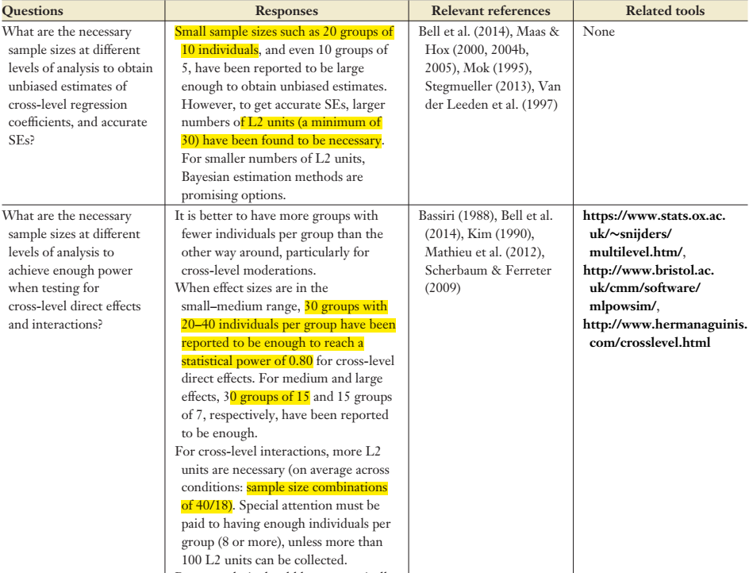

## Tamaño de la muestra: algunas indicaciones ([Hox et al., 2018](https://www.routledge.com/Multilevel-Analysis-Techniques-and-Applications-Third-Edition/Hox-Moerbeek-Schoot/p/book/9781138121362))

- ML
  - 30 grupos produce estimaciones precisas
- MLR
  - 10 grupos produce estimaciones precisas
  - Mejor cuando se tienen pocos grupos
- ML-SEM
  - 50-100 grupos (investigación transcultural)
  - 20 grupos (estimaciones bayesianas)
- 30/30: 30 grupos de 30 personas
  - Interés en los efectos fijos
- 50/20: 50 grupos de 20 personas
  - Interés en interacciones / MLM-SEM
- 100/10
  - 100 grupos de 10 personas
  - Interés en los efectos aleatorios
- 50/50: 50 grupos de 50 personas
  - Logísticos, datos ordinales

## Tamaño de la muestra: algunas indicaciones ([McNeish & Stapleton, 2016](https://link.springer.com/article/10.1007/s10648-014-9287-x))

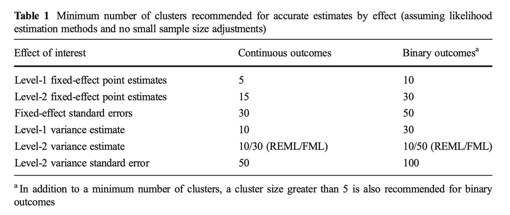

# Resumen

## Resumen

- Multinivel
  - Fenómenos + Teoría + Hipótesis + Datos
- Preparación de los datos
  - Formato largo
  - Centrado de variables
- Efectos fijos y aleatorios
  - Interceptos (diferentes variables de agrupamiento)
  - Pendientes (predictoras)
- Interpretaciones
  - Intra-grupo
  - Entre-grupos
- Extensiones…

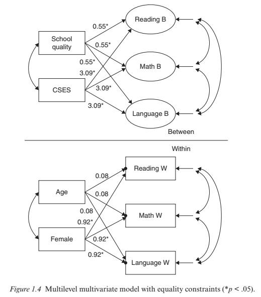

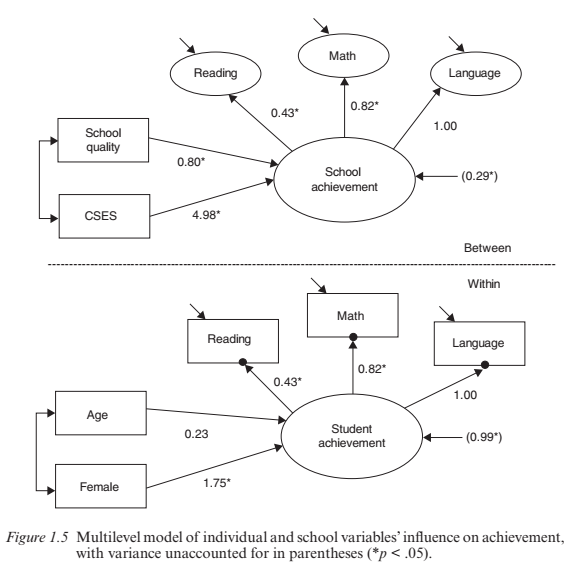

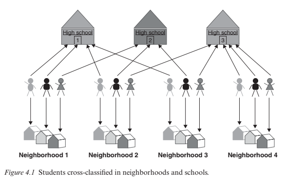

## Extensiones

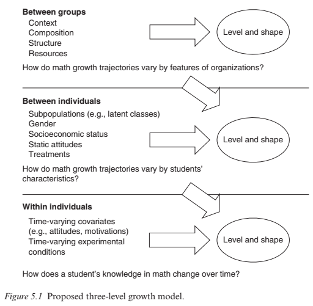

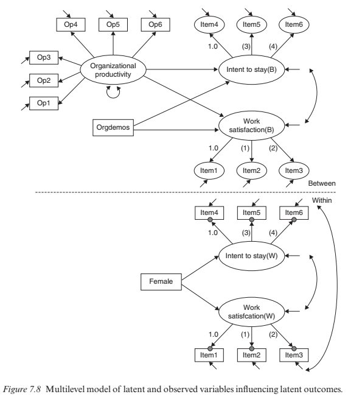